# Fish Permit Application

Al Irvine

Al Irvine  
New Graph Environment Ltd.  
al@newgraphenvironment  
250-777-1518  
Date: 2024-07-30

Ministry of Environment

**Re: Fish Permit Application**

This permit application can also be viewed online [at this link](https://newgraphenvironment.github.io/fish_passage_peace_2024_permit/). A summary of sites to be potentially assessed is included as Tables 2 - 3, details of fish species potentially encountered is presented in Table 4 and an overview map displaying potential sample locations is included as Figure 1. A kml file of the sites is included as an attachment to the application and can also be downloaded [from here at this link](https://github.com/NewGraphEnvironment/fish_passage_peace_2024_permit/raw/main/docs/sites_peace_2024_20240730_kml.zip). Please note that there is an extensive amount of information contained in the kml file (accessed by clicking on sites) including brief summaries of background reporting data (when available).

## Brief description of project/activities

This work is a multi-year collaboration of many groups and an initiative of the Society for Ecosystem Restoration Northern BC. Funding for the project is through the Fish and Wildlife Compensation Program and the Provincial Fish Passage Technical Working Group. Al Irvine, R.P.Bio from New Graph Environment Ltd. is leading the fieldwork with field and office collaboration with teams from McLeod Lake Indian Band. Past reports are below:

- https://newgraphenvironment.github.io/Parsnip_Fish_Passage/
- https://newgraphenvironment.github.io/fish_passage_parsnip_2021_reporting/
- https://newgraphenvironment.github.io/fish_passage_peace_2022_reporting/
- https://newgraphenvironment.github.io/fish_passage_peace_2023_reporting/

## Rationale

Rationale for sampling is to inform fish presence/absence, species composition/density, abundance estimates, movement, growth, and survival as part of habitat confirmations and effectiveness monitoring related to fish passage restoration at barrier culverts. Habitat confirmation methodology information can be referenced in the above reports which builds on the [Fish Passage Technical Working Group Phase 2 protocol](https://www2.gov.bc.ca/gov/content/environment/natural-resource-stewardship/land-based-investment/investment-categories/fish-passage). Presence/absence of fish, species composition/abundance, distribution limits and fish movement can be useful for prioritizing which crossings are a best fit for fish passage restoration and inform follow up effectiveness monitoring.

## Methodologies

Sampling is proposed at streams included in Tables 2 - 3 where we will be performing habitat confirmations and follow up site visits related to past habitat confirmations/fish passage remediations.

Sampling methodologies will be dependent on the site, fish species suspected, type of habitat encountered, risks to aquatic organisms potentially present and ongoing communications. Sampling methods may include minnowtrapping, electrofishing, and dipnetting upstream and downstream of current and past barrier culvert locations.

### 0.0.1 PIT Tagging

As part of this permit application we are proposing tagging. Our study plan is (when time allows and PIT tagging is expected to increase our state of knowledge about the subject system) to electrofish small sites both upstream and downstream of priority culvert “barrier” sites and insert biomark APT12 PIT tags into the body cavity of select fish captured over 60mm. Fish location (UTM), length and weight will also be collected. In addition to providing information on abundance upstream and downstream of potential culvert restoration sites, the study will also provide information for monitoring programs to document fish movement, growth and survival at sites over multi-year timeframes. Main objectives are to determine

1. if fish are moving into restored areas
2. if before any remediation is conducted - fish are moving through sites where stream crossing structures (culverts) likely cause connectivity issues
3. evaluate if productivity of the systems are increasing following bridge installation and/or if fish are moving upstream/downstream of where replaced/removed structures are located

As we wish to tag all fish over 60mm in each site sampled we would like to apply for a permit allowing a maximum of 600 fish with a maximum of 150 fish/stream. Although we are requesting a maximum of 150 fish/stream, we have listed 150 fish of each species per stream because we will not know the species composition of the sites until the sampling occurs.

In general, species likely to be tagged include rainbow trout, bull trout and burbot. The numbers of fish per stream are likely to be much less than 150 however we are requesting the maximum number of fish to be tagged to allow for flexibility in the field. In 2023 the maximum number of fish tagged at one site was less than 100 with a total of 2 burbot tagged.

## Risks associated with project/activities and associated mitigation

Table 1: Risks and mitigation

| Impact | Mitigation |
| --- | --- |
| High Voltage Injuries | Use the minimum effective voltage |
| Disruption of Spawning | Avoid electrofishing during highest risk periods in likely spawning habitat |
| Physical Stress on Fish | Quick handling and release of captured fish |
| Injury from PIT Tagging Surgeries | Shallow insertion and use fresh syringes every 10 surgeries |

Please note that the sampling will be completed before October 31 (end of August till mid-September however the end-date of the sampling period is listed as Dec 31 on the application to allow time outside of the busy field season for the data to be processed, QA’d and organized so that required reporting can be as informative as possible when submitted. An example of how we have been presenting results and methodologies from past assessments can be referenced [here at this link](https://newgraphenvironment.github.io/fish_passage_peace_2023_reporting/).

Please do not hesitate to contact me if you need more information or have any questions or concerns.

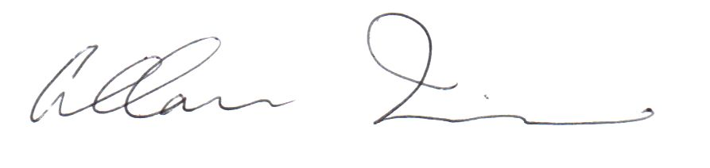

Al Irvine, R.P.Bio

[figure not shown]

Figure 1: Location of potential sample sites.

Table 2: Potential sampling locations.

| id | stream_name | wsc_code | lat | long | watershed_group_code |
| --- | --- | --- | --- | --- | --- |
| 125000 | tributary to Parsnip River | 236-738000-00000-00000-0000-0000-000-000-000-000-000-000 | 54.48563 | -121.8031 | PARS |
| 125179 | Unnamed tributary to Missinka River | 236-614900-20900-03300-0000-0000-000-000-000-000-000-000 | 54.61806 | -121.9112 | PARS |
| 125180 | tributary to Missinka River | 236-614900-20900-00000-0000-0000-000-000-000-000-000-000 | 54.62006 | -121.9211 | PARS |
| 125231 | tributary to Table River | 236-450800-15400-00000-0000-0000-000-000-000-000-000-000 | 54.73106 | -122.2241 | PARS |
| 125261 | Fern Creek | 236-358400-00000-00000-0000-0000-000-000-000-000-000-000 | 54.75598 | -122.4624 | PARS |
| 198667 | Tsatchuka Creek | 230-906800-65600-00000-0000-0000-000-000-000-000-000-000 | 54.95494 | -122.9900 | CARP |
| 198668 | Tributary to McLeod Lake | 230-906800-71800-00000-0000-0000-000-000-000-000-000-000 | 54.93729 | -122.9692 | CARP |
| 198692 | Tributary to Kerry Lake | 230-906800-97600-22400-0000-0000-000-000-000-000-000-000 | 54.68106 | -122.8180 | CRKD |

Table 3: Potential sample site details

| id | stream_name | sp_upstr | fish_tags |
| --- | --- | --- | --- |
| 125000 | tributary to Parsnip River | – | 150 |
| 125179 | Unnamed tributary to Missinka River | BT;RB | 150 |
| 125180 | tributary to Missinka River | RB | 150 |
| 125231 | tributary to Table River | RB | 150 |
| 125261 | Fern Creek | BB;C;CBC;DC;DV;LSU;RB;RSC;SU | 150 |
| 198667 | Tsatchuka Creek | CCG;RB | 150 |
| 198668 | Tributary to McLeod Lake | – | 150 |
| 198692 | Tributary to Kerry Lake | – | 150 |

Table 4: Fish species recorded within subject streams in the Fisheries Information Summary System.

| Scientific Name | Species Name | Species Code | BC List | Provincial FRPA | COSEWIC | SARA |
| --- | --- | --- | --- | --- | --- | --- |
| Catostomus catostomus | Longnose Sucker | LSU | Yellow | – | – | – |
| Catostomus commersonii | White Sucker | WSU | Yellow | – | – | – |
| Catostomus macrocheilus | Largescale Sucker | CSU | Yellow | – | – | – |
| Coregonus clupeaformis | Lake Whitefish | LW | Yellow | – | – | – |
| Cottus aleuticus | Coastrange Sculpin (formerly Aleutian Sculpin) | CAL | Yellow | – | – | – |
| Cottus asper | Prickly Sculpin | CAS | Yellow | – | – | – |
| Cottus cognatus | Slimy Sculpin | CCG | Yellow | – | – | – |
| Cottus hubbsi | Mottled Sculpin | CBA | Blue | – | SC (Nov 2010) | 1-SC (Jun 2003) |
| Couesius plumbeus | Lake Chub | LKC | Yellow | – | DD | – |
| Lota lota | Burbot | BB | Yellow | – | – | – |
| Mylocheilus caurinus | Peamouth Chub | PCC | Yellow | – | – | – |
| Oncorhynchus mykiss | Rainbow Trout | RB | Yellow | – | – | – |
| Oncorhynchus nerka | Kokanee | KO | Yellow | – | – | – |
| Osmerus dentex | Rainbow Smelt | RSM | Unknown | – | – | – |
| Prosopium coulterii | Pygmy Whitefish | PW | Yellow | – | NAR (Nov 2016) | – |
| Prosopium cylindraceum | Round Whitefish | RW | Yellow | – | – | – |
| Prosopium williamsoni | Mountain Whitefish | MW | Yellow | – | – | – |
| Ptychocheilus oregonensis | Northern Pikeminnow | NSC | Yellow | – | – | – |
| Rhinichthys cataractae | Longnose Dace | LNC | Yellow | – | – | – |
| Richardsonius balteatus | Redside Shiner | RSC | Yellow | – | – | – |
| Salvelinus confluentus | Bull Trout | BT | Blue | Y (Jun 2006) | SC (Nov 2012) | – |
| Salvelinus fontinalis | Brook Trout | EB | Exotic | – | – | – |
| Salvelinus malma | Dolly Varden | DV | Yellow | – | – | – |
| Salvelinus namaycush | Lake Trout | LT | Yellow | – | – | – |
| Thymallus arcticus | Arctic Grayling | GR | Yellow | – | – | – |
| – | Chub (General) | CBC | – | – | – | – |
| – | Dace (General) | DC | – | – | – | – |
| – | Minnow (General) | C | – | – | – | – |
| – | Sculpin (General) | CC | – | – | – | – |
| – | Sucker (General) | SU | – | – | – | – |
| – | Whitefish (General) | WF | – | – | – | – |